# Kohler EDA Analysis

Michael Kohler

March 25, 2019

## R Markdown

So for this project I used NHGIS census data from 1850, 1860, and 1870, focusing on total population, race breakdown, and slavery status.

I had to redo the entire project a couple times when I realized I had set up my .csv’s in stupid ways, including doing dumb stuff like leaving the labels for various columns as they are in the census. Though, looking back, I wonder if I could have just fixed it all within R by mutating columns into new, relabled columns. Still, it was good practice on dealing with different github versions as I kept uploading new versions of the .csvs.

And it took me WAY longer than it should have to figure out how to get all 5 .csv’s into one data set. But I did it, dammit.

Obviously in retrospect just looking at a few numbers over 3 censuses is pretty limited, particularly as I was mostly interested in Fairfax County (dissertation related). But hey, as I said, I’m feeling pretty accomplished that I even managed to get this stuff together for later analysis. Though, of course, most of this work would have been unnecessary if I had just figured out how to get the NHGIS stuff to download as one .csv in the first place… *eyeroll*

```r
popdata_ffx <- popdata %>%
  filter(STATE == "Virginia", COUNTY == "Fairfax") %>%
  rowwise %>%
  mutate(total_black = (sum(total_free_black, total_slave, na.rm = TRUE)))
```

## Including Plots

Quick and dirty line chart of the data:

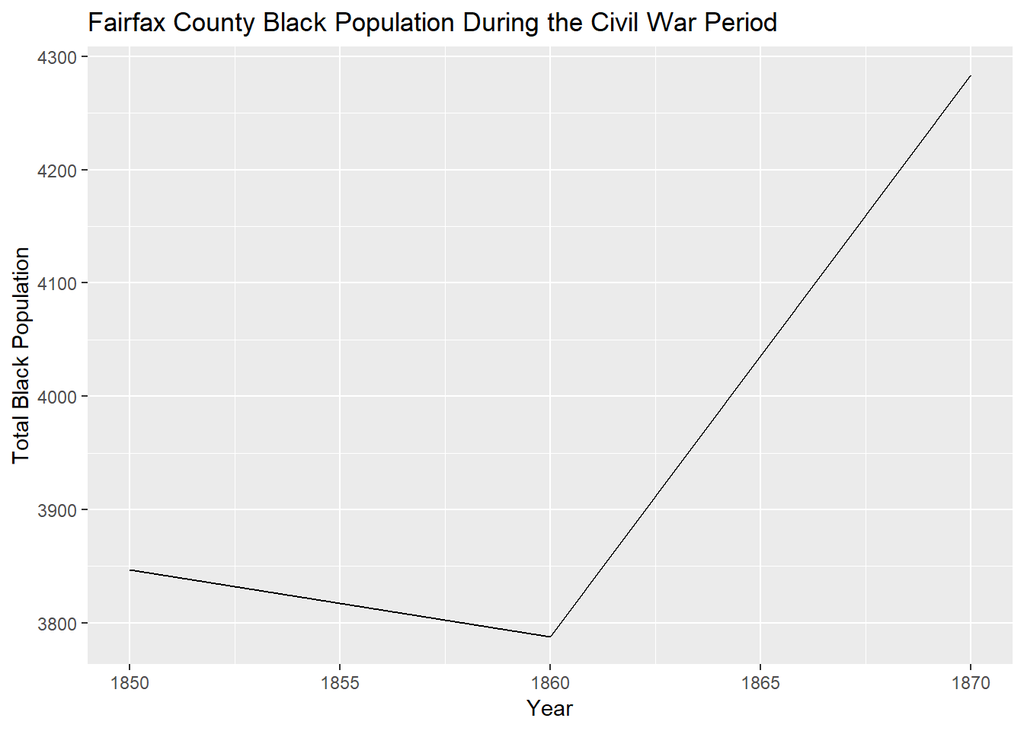